# Going online to go the distance?: Estimating relationship durations among online and offline daters

Nicholas Velotta | ndv24@uw.edu

Winter 2021

# 1 Introduction:

During what was meant to be the company’s first major television interview, Match.com founder, Gary Kremen declared his site would “bring more love to the planet than anything since Jesus Christ” (Slater, 2014). This would be a gutsy claim for a CEO to make in 2021; it was almost delusive for Kremen to propose such success in 1995 when approximately five percent of the U.S. population had internet access (Kauflin, 2011). It’s worth mentioning that Kremen was wearing a tie-dye shirt and insisted on taking the interview seated in a beanbag chair at the time. Today, Match Group includes its namesake site along with apps and sites like Tinder, PlentyOfFish, OkCupid, Hinge, and Pairs, it is valued at over $45 billion dollars, and commands a dating pool with hundreds of millions of users (Gurdus, 2021). Upon second look, Kremen’s prophecy may actually seem *prescient*.

## 1.1 Online dating: changing intimacy one swipe at a time?

Few aspects of romantic relationships have shifted as radically in the past fifty years than how we find our mates. Less than a century ago people around the world primarily found their partners through *familial networks*—for example, through formal and informal forms of matchmaking and/or arranged-marriages. The only other significant mediators of relationship formation were *proximity and interaction* (i.e., people tended to marry the available mates around them geographically and those they saw most frequently) (Coontz, 2006). The number of couples who meet through community-sourced matchmaking is now a vanishing minority. Instead, a majority share of American couples now find their partners online or on dating apps (M. J. Rosenfeld et al., 2019). In a previous article (Schwartz & Velotta, 2018b), I reviewed the literature on online dating’s rise in popularity here and around the globe, however, while writing that article the lack of available information on people’s behaviors and experiences using online dating was striking. The dearth of empirical knowledge on how online daters find (or, perhaps, *do not* find) partners can be attributed to the privatization of all major matchmaking websites; the data that users generate is the property of the online dating companies. Such is the situation that the mechanisms which lead to forty percent (or more) of all new relationships, marriages, and sexual encounters are unknown to the scientific community (M. J. Rosenfeld et al., 2019). In effect, relationship scientists are operating with little more than anecdotes and self-reports of online dating behavior from a handful of surveys and interview-based studies. And the closest academics get to analyses of user data appear in the form of company press-releases on the efficacy of matching algorithms. Of course, these press-releases are suspected of bias, conceal the raw data, and lack explanations of statistical methods. Until online dating companies are forthcoming with their data and practices, researchers need to develop innovative techniques to study online dating behavior.

## 1.2 Current project

While this exploratory project will not establish those techniques, it builds towards my ability to do so given the time limitations of the course. By using the most credible source of longitudinal data on relationships formed online, the How Couples Meet and Stay Together survey (HCMST), I will evaluate the dissolution rates of relationships that have been formed online versus offline. Modeling a form of relationship stability (i.e. staying together) using the nationally representative sample provided by the most notable researcher of modern dating patterns, I aim to: (1) become familiar with the six waves of data generated by the HCMST, (2) apply relevant statistical methods to understanding relationship life cycles (i.e., a form of event history analysis), and (3) understand the relative frequency of online daters’ reentry into the single dating pool compared to offline daters. Considering that the widespread use of dating services took place alongside a (relatively) recent plateau in the national divorce rate (Cohen, 2019), I expect:

### 1.2.1 Hypotheses

> $H_{1}:$ *The likelihood of separating will not differ between individuals who met their partner online versus those that met their partners offline.*

Because it has long been observed that American men tend to have more relationships across their life spans compared to American women (Schwartz & Velotta, 2018a), and because men to also have more concurrent relationships (i.e., parallel relationships with multiple people at a time) (Paik, 2010), I also anticipate:

> $H_{2}:$ *Males will have higher likelihoods of dissolution than women, regardless of how the relationship was initiated.*

# 2 Methods

## 2.1 Data set and sample characteristics

I will use the first six waves (2009-2017) of the [HCMST](https://data.stanford.edu/hcmst) to predict the likelihood of dissolution across relationships formed online versus those formed offline. To indicate how a respondent met their partner, I will use a recalibrated `either_internet_adjusted` variable which Rosenfeld et al. (2018) coded as either “met online,” “not met online,” and “probably not met online” based on respondents answers to two items asking first whether they met their current romantic partner online, and second prompting respondents to provide a text entry describing how they met their partner. The researchers compared the two types of responses for each individual and sorted the participants who answered incongruously on the items into the most appropriate category for analysis (i.e., met online, met offline, or probably did not meet online). For my analysis I created the binary factor variable `met_online` which collapses the response values into: 1 = “met online” and 0 = “met offline.” Below in Table 2.1 you can see my sample’s distribution on `met_online`.

```r
#check counts for online vs offline
all_filtered_hcmst %>% group_by(met_online) %>%
    summarise(n = n()) %>%
    mutate(`%` = n / sum(n) * 100) %>%
    mutate(`%` = `%` %>% round(3)) %>%
    kable(caption = "Counts for online versus offline relationship initiation") %>%
    kable_styling(bootstrap_options = c("striped", "hover", "condensed", "responsive"))
```

Table 2.1: Counts for online versus offline relationship initiation

met_online

n

%

0. met offline

2715

90.47

1. met online

286

9.53

My project will also consider the biological sex as a covariate for predicting relationship dissolution. The variable provided by HCMST `ppgender` has been transformed into the binary variable `biosex` (1 = male; 0 = female) with a distribution shown in Table 2.2.

```r
#check counts for gender dist
all_filtered_hcmst %>% group_by(biosex) %>%
    summarise(n = n()) %>%
    mutate(`%` = n / sum(n) * 100) %>%
    mutate(`%` = `%` %>% round(3)) %>%
    kable(caption = "Counts for biological sex distribution of sample (male = 1 , female = 0)") %>%
    kable_styling(bootstrap_options = c("striped", "hover", "condensed", "responsive"))
```

Table 2.2: Counts for biological sex distribution of sample (male = 1 , female = 0)

| biosex | n | % |
| --- | --- | --- |
| 0 | 1485 | 49.484 |
| 1 | 1516 | 50.516 |

## 2.2 Data wrangling

This analysis uses a parameter covariate (PC) regression, an expanded-on and generalized variation of a generalized linear model (GLM), which enables me to fit my longitudinal data set to new distributions outside of those distributions typically available to GLMs (which can be limiting). In particular, I fit my data to a PC model using the Weibull distribution so that the parameters of my model change in response to fluctuations in the model’s covariates (`met_online` and `biosex`).

Working with the HCMST data set presented a few challenges worth mentioning. First, and most importantly, the researchers were not always consistent with how they recorded different variables or even *if* they recorded them. For example, the data set included day counts “since respondent’s completion of wave 1” for wave 2 and wave 3 but did not include any day counts for subsequent waves (4-6). To account for the missing duration data—which was essential for conducting any kind of event history analysis—I found the data collection windows for each wave, averaged out the dates to a midpoint between the beginning of a wave’s data collection process and the conclusion of a wave’s data collection process, and I used this midpoint date as the my indicator of when a given wave was administered for all participants (see Equation (2.1)). After calculating all midpoints for waves 1-6, I calculated the number of days elapsed since wave 1 (see Equation (2.2)). This process allowed me to estimate how long people remained in the study based on these wave data collection times. I then calculated relationship durations using the `rel_dur_prior` variable, which was created from the raw `how_long_relationship` variable that asked how long participants had been with their partner at the time of taking wave 1. HCMST recorded prior relationship durations in years, I converted this to duration in days (rounded to the nearest full day). All those that had a missing value for `rel_dur_prior` were dropped from my sample ( *n* = 5) because they could neither be right censored nor interval censored—this did not affect the significance or directions of any of my results in any meaningful way.

$$\begin{equation}
\mbox{Midpoint of wave (x)} = \frac {\mbox{(Start date of data collection for wave (x)) + (End date of data collection for Wave (x))}}{2}
\tag{2.1}
\end{equation}$$

$$\begin{equation}
\mbox{Wave (x)'s time elapsed since wave 1} = \mbox{(Wave 1 data collection date) + ((Midpoint of wave (x)) - (Wave 1 data collection date))}
\tag{2.2}
\end{equation}$$

I then created vectors containing each participants’ respective $t_o$ (when they entered their current relationship) and $t_c$ (what wave they left the study due to a break-up). Those without a $t_c$ are participants that were still in a relationship with their partner at the time of the last wave (wave 6), and so they have been right censored. I used a loop (below) to create the “time open” and “time close” vectors.

```r
t_o = t_c = last_ind = rep(NA, nrow(hcmst_filtered))


for(i in 1:nrow(hcmst_filtered)) { #instructs index i to update until reachs n of rows in dataset
  rel_status_temp = c(hcmst_filtered[i, 5], hcmst_filtered[i, 8], hcmst_filtered[i, 11], hcmst_filtered[i, 13],
    hcmst_filtered[i, 14]) #pulling values from each col (i)
 last_index = last(which(rel_status_temp == 1))  #every vector we create will be 5 elements long, this will find which out of 5 we have a value of 1
 last_index = ifelse(is.na(last_index), 0, last_index) #rather than testing for NA status, rec NAs as a 0
 last_ind [i] = last_index
 if(last_index == 0) {
   t_o [i] =  hcmst_filtered[i, 4] #the number of days p was in relationship before wave 1 = to if they haven't broken up
   t_c [i] = hcmst_filtered[i, 4] + hcmst_filtered[i, 6] #will give us interval censoring betwn w1-w2
 }
 if(last_index == 1) {
   t_o [i] = hcmst_filtered[i, 4] + hcmst_filtered[i, 6]
   t_c [i] = hcmst_filtered[i, 4] + hcmst_filtered[i, 9] #counting the time before w1 and w2 accounts for diff in time recorded in `time elapsted var`
 }
 if(last_index == 2) {
   t_o [i] = hcmst_filtered[i, 4] + 819 #days btw w3 and w1
   t_c [i] = hcmst_filtered[i, 4] + 1678
 }
 if(last_index == 3) {
   t_o [i] = hcmst_filtered[i, 4] + 1678
   t_c [i] = hcmst_filtered[i, 4] + 2134
 }
 if(last_index == 4) {
   t_o [i] = hcmst_filtered[i, 4] + 2134
   t_c [i] = hcmst_filtered[i, 4] + 3068
 }
 if(last_index ==5) {
   t_o[i] = hcmst_filtered[i, 4] + 3068
   t_c [i] = Inf
 }

}

t_o = as_vector(t_o)
t_c = as_vector(t_c)
```

## 2.3 Data analysis

The HCMST has no exact observations besides `rel_dur_prior` measuring the number of days a couple had been together before entry into the study. To account for this, I conducted interval censoring and a left truncation of the data. This can be accomplished by taking the difference of the $t_o$ and $t_c$ survival functions and dividing by the survival function at `rel_dur_prior` (see Equation (2.3). I also created the exponentiated linear predictor, which in the case of Weibull distributions is also the *characteristic life* (i.e., the time at which 63.2% of units will experience my event of interest) and multiplied it across all individuals in my sample. This essentially creates a baseline parameter estimate measuring *each individual’s* characteristic life.

$$\begin{equation}
\mbox{Characteristic life} = \frac{S_{t_{o}} - S_{t_{c}}}{S_{\mbox{dur_rel_prior}}}
\tag{2.3}
\end{equation}$$

### 2.3.1 Parameters

Given the properties of the Weibull distribution’s shape parameter $c$, whereby $c = 1$ implies 0 variation in shape parameters as covariates change—i.e., a negative exponential distribution. This makes setting $c = 1$ an ideal first model to test regarding the shape parameter. My results will let me know where the data is pulling my shape parameter towards (whether it is below or above a value of 1). I anticipate a value lower than 1 for $c$ which would infer that a longer duration for a given relationship would correlate with a lower risk of breaking up at a given time point. Or, more plainly: the longer a couple has been together, the more likely they are to *stay* together.

Because my two covariates (`met_online`) and (`biosex`) are both binary factor variables, I will need to model various combinations of these covariates to assess the model’s coefficient predictions for different groups of people. For example, setting `met_online` and `biosex` both to 0 produces a model looking at females who met their partners offline; whereas setting `met_online` and `biosex` both to 1 produces a model looking at males who met their partners online.

```r
temp_dat = data.frame(t_o, t_c, rel_dur_prior = hcmst_filtered$rel_dur_prior,
                      met_online = hcmst_filtered$met_online, biosex = hcmst_filtered$biosex) %>%  na.omit()
temp_dat$met_online = as.numeric(temp_dat$met_online)-1

#################
#for Weibull PC1:
 y = temp_dat[,1:3]
 pars = c(b = median(temp_dat[,1]), c = 1, met_online=0, biosex=0) #testing neg exp w/ c =1
 X = as.matrix(temp_dat[,4:5])

logProb.WeibullPC = function(pars, y, X){
  b = pars[1]
  c = pars[2] #Weibull shape parameter
  gammas = pars[3:4]; names(gammas) = c("met_online", "biosex") #gammas will have regression coeffs labels
  b_i = b*exp(colSums(gammas*t(X))) #b para for each individual (bc this responds to covariates)--recall: characteristic life = the exponentiated linear predictor

  return(
     log(
        (pweibull(q = y$t_o, scale = b_i, shape = c, lower.tail = F, log.p = F) - # taking the diff of s(t)s BEFORE they are logged
          pweibull(q = y$t_c, scale = b_i, shape = c, lower.tail = F, log.p = F))
          / #divide by s(t) at `rel_dur_prior`
          pweibull(q = y$rel_dur_prior, scale = b_i, shape = c, lower.tail = F, log.p = F))
     ) #doing left truncation
}

WeibullPC = maxLik(
  logLik = logProb.WeibullPC,
 y = y,
 start = pars, #testing neg exp w/ c =1
 X = X,
 method = "BHHH")
```

# 3 Results

## 3.1 Weibull PC Model 1 ($c = 1$, Negative Exponential)

```r
#RESULTS for PC 1

summary(WeibullPC) # has c = 1, mo = 0, bs = 0
```

```
## --------------------------------------------
## Maximum Likelihood estimation
## BHHH maximisation, 9 iterations
## Return code 8: successive function values within relative tolerance limit (reltol)
## Log-Likelihood: -1355.735
## 4  free parameters
## Estimates:
##             Estimate Std. error t value  Pr(> t)
## b          446.78047   99.82659   4.476 7.62e-06 ***
## c            0.61781    0.03833  16.119  < 2e-16 ***
## met_online  -0.01596    0.16877  -0.095    0.925
## biosex       0.07463    0.13865   0.538    0.590
## ---
## Signif. codes:  0 '***' 0.001 '**' 0.01 '*' 0.05 '.' 0.1 ' ' 1
## --------------------------------------------
```

$H_2$ (males will have significantly shorter relationship durations than females) is unsupported by **all** models I ran.

## 3.2 Weibull PC Model 2 ($c = 0.5$)

```r
#################
#for Weibull PC2:
 y = temp_dat[,1:3]
 pars = c(b = median(temp_dat[,1]), c = .5, met_online=1, biosex=0) #testing neg exp w/ c =1
 X = as.matrix(temp_dat[,4:5])

logProb.WeibullPC = function(pars, y, X){
  b = pars[1]
  c = pars[2] #Weibull shape parameter
  gammas = pars[3:4]; names(gammas) = c("met_online", "biosex") #gammas will have regression coeffs labels
  b_i = b*exp(colSums(gammas*t(X))) #b para for each individual (bc this responds to covariates)--recall: characteristic life = the exponentiated linear predictor

  return(
     log(
        (pweibull(q = y$t_o, scale = b_i, shape = c, lower.tail = F, log.p = F) - # taking the diff of s(t)s BEFORE they are logged
          pweibull(q = y$t_c, scale = b_i, shape = c, lower.tail = F, log.p = F))
          / #divide by s(t) at `rel_dur_prior`
          pweibull(q = y$rel_dur_prior, scale = b_i, shape = c, lower.tail = F, log.p = F))
     ) #doing left truncation
}

WeibullPC2 = maxLik(
  logLik = logProb.WeibullPC,
 y = y,
 start = pars, #testing neg exp w/ c =1
 X = X,
 method = "BHHH")

#RESULTS FOR PC 2
summary(WeibullPC2) #has c = .5, mo = 1, bs = 0
```

```
## --------------------------------------------
## Maximum Likelihood estimation
## BHHH maximisation, 8 iterations
## Return code 8: successive function values within relative tolerance limit (reltol)
## Log-Likelihood: -1355.735
## 4  free parameters
## Estimates:
##             Estimate Std. error t value Pr(> t)
## b          446.76979   99.81372   4.476 7.6e-06 ***
## c            0.61785    0.03833  16.120 < 2e-16 ***
## met_online  -0.01588    0.16876  -0.094   0.925
## biosex       0.07473    0.13863   0.539   0.590
## ---
## Signif. codes:  0 '***' 0.001 '**' 0.01 '*' 0.05 '.' 0.1 ' ' 1
## --------------------------------------------
```

Here, looking at females who met their partners **online**, the characteristic life of their partnerships is approximately 446.7697938 days (Std error: 99.8137172, $p>.000$).

## 3.3 Weibull PC Model 3 ($c = 0.5$)

```r
#For Weibull PC3:
 y = temp_dat[,1:3]
 pars = c(b = median(temp_dat[,1]), c = .5, met_online=0, biosex=1) #testing neg exp w/ c =1
 X = as.matrix(temp_dat[,4:5])

logProb.WeibullPC = function(pars, y, X){
  b = pars[1]
  c = pars[2] #Weibull shape parameter
  gammas = pars[3:4]; names(gammas) = c("met_online", "biosex") #gammas will have regression coeffs labels
  b_i = b*exp(colSums(gammas*t(X))) #b para for each individual (bc this responds to covariates)--recall: characteristic life = the exponentiated linear predictor

  return(
     log(
        (pweibull(q = y$t_o, scale = b_i, shape = c, lower.tail = F, log.p = F) - # taking the diff of s(t)s BEFORE they are logged
          pweibull(q = y$t_c, scale = b_i, shape = c, lower.tail = F, log.p = F))
          / #divide by s(t) at `rel_dur_prior`
          pweibull(q = y$rel_dur_prior, scale = b_i, shape = c, lower.tail = F, log.p = F))
     ) #doing left truncation
}

WeibullPC3 = maxLik(
  logLik = logProb.WeibullPC,
 y = y,
 start = pars, #testing neg exp w/ c =1
 X = X,
 method = "BHHH")

#RESULTS FOR PC3
summary(WeibullPC3) #has c = .5, met_online=0, biosex=1
```

```
## --------------------------------------------
## Maximum Likelihood estimation
## BHHH maximisation, 9 iterations
## Return code 8: successive function values within relative tolerance limit (reltol)
## Log-Likelihood: -1355.735
## 4  free parameters
## Estimates:
##             Estimate Std. error t value  Pr(> t)
## b          446.76663   99.80633   4.476 7.59e-06 ***
## c            0.61787    0.03833  16.121  < 2e-16 ***
## met_online  -0.01584    0.16875  -0.094    0.925
## biosex       0.07481    0.13862   0.540    0.589
## ---
## Signif. codes:  0 '***' 0.001 '**' 0.01 '*' 0.05 '.' 0.1 ' ' 1
## --------------------------------------------
```

Here, looking at males who met their partners **offline**, the characteristic life of their partnerships is approximately 446.7666339 days (Std error: 99.8063326, $p>.000$).

## 3.4 Weibull PC Model 4 ($c = 0.5$)

```r
#################
#For Weibull PC4:
 y = temp_dat[,1:3]
 pars = c(b = median(temp_dat[,1]), c = .5, met_online=1, biosex=1) #testing neg exp w/ c =1
 X = as.matrix(temp_dat[,4:5])

logProb.WeibullPC = function(pars, y, X){
  b = pars[1]
  c = pars[2] #Weibull shape parameter
  gammas = pars[3:4]; names(gammas) = c("met_online", "biosex") #gammas will have regression coeffs labels
  b_i = b*exp(colSums(gammas*t(X))) #b para for each individual (bc this responds to covariates)--recall: characteristic life = the exponentiated linear predictor

  return(
     log(
        (pweibull(q = y$t_o, scale = b_i, shape = c, lower.tail = F, log.p = F) - # taking the diff of s(t)s BEFORE they are logged
          pweibull(q = y$t_c, scale = b_i, shape = c, lower.tail = F, log.p = F))
          / #divide by s(t) at `rel_dur_prior`
          pweibull(q = y$rel_dur_prior, scale = b_i, shape = c, lower.tail = F, log.p = F))
     ) #doing left truncation
}

WeibullPC4 = maxLik(
  logLik = logProb.WeibullPC,
 y = y,
 start = pars, #testing neg exp w/ c =1
 X = X,
 method = "BHHH")

#RESULTS FOR PC4
summary(WeibullPC4) #has c = .5, met_online=1, biosex=1
```

```
## --------------------------------------------
## Maximum Likelihood estimation
## BHHH maximisation, 11 iterations
## Return code 8: successive function values within relative tolerance limit (reltol)
## Log-Likelihood: -1355.735
## 4  free parameters
## Estimates:
##             Estimate Std. error t value  Pr(> t)
## b          446.77920   99.82202   4.476 7.61e-06 ***
## c            0.61782    0.03833  16.119  < 2e-16 ***
## met_online  -0.01593    0.16877  -0.094    0.925
## biosex       0.07467    0.13864   0.539    0.590
## ---
## Signif. codes:  0 '***' 0.001 '**' 0.01 '*' 0.05 '.' 0.1 ' ' 1
## --------------------------------------------
```

The relationships of males who met their partners **online** have a characteristic life of 446.7791964 days (Std error: 99.8220247, $p>.000$).

## 3.5 Relationship durations pre-W1

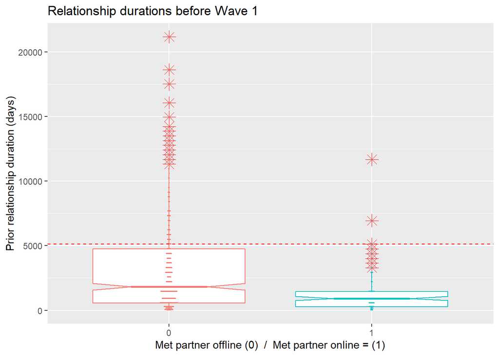

```r
#boxplot(rel_dur_prior ~ met_online, temp_dat)
#abline(h = 5113)

boxplot_met <- ggplot(temp_dat, aes(x = as.factor(met_online), y = rel_dur_prior, color = as.factor(met_online))) +
  geom_boxplot(outlier.colour="red", outlier.shape=8,
                outlier.size=4, notch=TRUE)

boxplot_met <- boxplot_met + geom_dotplot(binaxis='y', stackdir='center', dotsize=1, binwidth = 20)+
  labs(title="Relationship durations before Wave 1",x="Met partner offline (0)  /  Met partner online = (1)", y = "Prior relationship duration (days)") +
  theme(legend.position="none") +
  geom_hline(yintercept=5113, linetype="dashed", color = "red")

boxplot_met
```

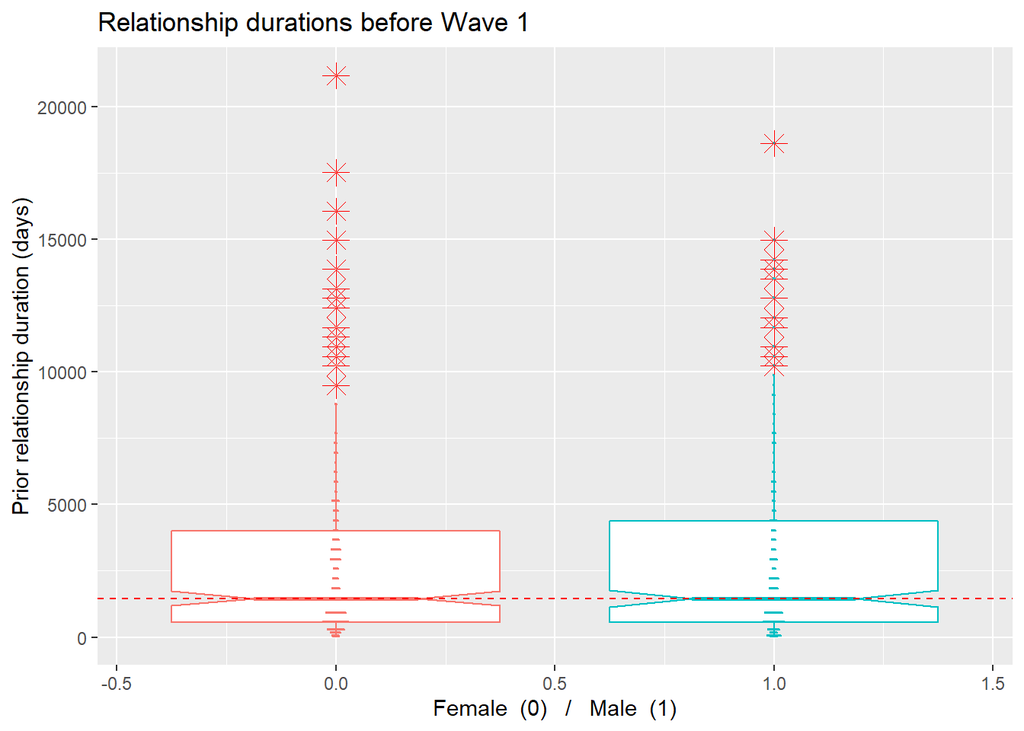

```r
#boxplot(rel_dur_prior ~ met_online, temp_dat)
#abline(h = 5113)

boxplot_sex <- ggplot(temp_dat, aes(x = biosex, y = rel_dur_prior, group = biosex, color = as.factor(biosex))) +
  geom_boxplot(outlier.colour="red", outlier.shape=8,
                outlier.size=4, notch=TRUE)

boxplot_sex + geom_dotplot(binaxis='y', stackdir='center', dotsize=1, binwidth = 20)+
  labs(title="Relationship durations before Wave 1",x="Female  (0)   /   Male  (1)", y = "Prior relationship duration (days)") +
  theme(legend.position="none") +
  geom_hline(yintercept= median(temp_dat$rel_dur_prior), linetype="dashed", color = "red")
```

# 4 Discussion

While online dating services have certainly changed the way we find partners, perhaps less changed are those core elements that attract us to partners suitable for long-term, relatively stable relationships. Indeed, some of us are better than others at finding their *One*, their *soulmate*…others, may just be luckier. But one thing this report *cannot* support is a narrative in which meeting a partner online is the mediator between a relationship going the distance and a relationship sputtering out.

This provides information for relationship researchers trying to understand how the biggest revolution in mate selection, the invention of online/app dating has (or even, has not) affected relationship patterns and life cycles for a majority share of Americans.

## 4.1 Limitations

# 5 References

Cohen, P. N. (2019). The Coming Divorce Decline. *Socius*, *5*, 2378023119873497. https://doi.org/10.1177/2378023119873497

Coontz, S. (2006). *Marriage, a History: How Love Conquered Marriage*. Penguin Books. https://www.amazon.com/Marriage-History-How-Love-Conquered/dp/014303667X

Gurdus, L. (2021). Bumble vs Match Group: Two traders check out dating stocks ahead of Bumble’s IPO. *CNBC*. https://www.cnbc.com/2021/02/11/bumble-ipo-vs-match-group-traders-check-out-dating-stocks.html

Kauflin, J. (2011). How Match.com’s Founder Created The World’s Biggest Dating Website—And Walked Away With Just $50,000. *Business Insider*. https://www.businessinsider.com/match-gary-kremen-2011-12

Paik, A. (2010). The Contexts of Sexual Involvement And Concurrent Sexual Partnerships. *Perspectives on Sexual and Reproductive Health*, *42*(1), 33–42. https://doi.org/https://doi.org/10.1363/4203310

Rosenfeld, M. J., Thomas, R. J., & Hausen, S. (2019). Disintermediating your friends: How online dating in the United States displaces other ways of meeting. *Proceedings of the National Academy of Sciences*, *116*(36), 17753–17758. https://doi.org/10.1073/pnas.1908630116

Rosenfeld, M., Thomas, R. J., & Falcon, M. (2018). *How Couples Meet and Stay Together, Waves 1, 2, and 3: Public version 3.04, plus wave 4 supplement version 1.02 and wave 5 supplement version 1.0 and wave 6 supplement ver 1.0 [Computer files]*. Stanford University Libraries. https://data.stanford.edu/hcmst

Schwartz, P., & Velotta, N. (2018a). Gender and sexuality in aging. In B. J. Risman, C. Froyum, & W. J. Scarborough (Eds.), *Handbook of the Sociology of Gender* (2nd ed., pp. 329–347). Springer Press.

Schwartz, P., & Velotta, N. (2018b). Online Dating: Changing Intimacy One Swipe at a Time? In J. Van Hook, S. McHale, & V. King (Eds.), *Families and Technology* (Vol. 9). National Symposium on Family Issues.

Slater, D. (2014). Do we want online dating sites to be political activists? *Washington Post*. https://www.washingtonpost.com/opinions/do-we-want-online-dating-sites-to-be-political-activists/2014/04/18/9e2b66a0-c0d9-11e3-b574-f8748871856a_story.html

# 6 Source code

````
---
title: "Going online to go the distance?: Estimating relationship durations among online and offline daters"
author: "Nicholas Velotta | ndv24@uw.edu"
date: "Winter 2021"
header-includes: #allows you to add in your own Latex packages
- \usepackage{float} #use the 'float' package
- \floatplacement{figure}{H} #make every figure with caption = h
output:
    bookdown::html_document2:
        number_sections: true
        self_contained: true
        code_folding: hide
        toc: true
        toc_float:
            collapsed: true
            smooth_scroll: false
    pdf_document:
        number_sections: true
        toc: true
        fig_cap: yes
        keep_tex: yes
bibliography: ndv24_hw10_hcmst_bib.bib
csl: apa_single_spaced.csl
link-citations: true
urlcolor: blue
---

```{r setup, include=FALSE}
knitr::opts_chunk$set(echo = TRUE)
require(tidyr)
require(tidyverse)
require(ggplot2)
require(dplyr)
require(DT)
require(haven)
require(readstata13)
require(knitr)
require(kableExtra)
require(survival)
require(maxLik)
````

[output cut: 376 more lines]

[output not shown]